# RNAseAlert assay 15: Josie#4 in 384-well plate

Jan Sklenar

16/2/2021

## Goals

Repeat Centrum assay 1, including higher starting concentration of DNA. Using a simpler layout reduces any chance of error.

## Chemicals used in the assay

name | details

- 1M HEPES pH 6.8 filter sterilised
- 1M MgCl2 filter sterilised rNTP solution mix currently in SHERLOCK box, -20 Centrum T7 RNA polymerase currently in SHERLOCK box, -20 Centrum, reordered from NEB. Supplied at 50,000U/ml, needed at 5U/ul, made 10X dilution in supplied polymerase buffer (1.6ul enzyme in 14.4ul buffer).
- crRNA made dilution from fresh stock aliquot from -80 (TSL)
- Cas13 Cas13 protein 10x; 5ul of stock Cas13 (2mg/ml) diluted by adding 153ul of strorage buffer (SB)
- target DNA Dilutions in next sheet
- substrate Invitrogen Rnase Alert v2 kit, 50pmol per tube. Resuspended 3x tubes in 25ul supplied buffer each, to give 2uM substrate.
- benzonase 25U/ul

[figure not shown]

pipetting

## Data preparation

### Read data into R

```r
## read in raw data and some annotation
setwd("C:/1_R/aRmy/200327_RNAseAlert/RNAseAlert")
raw <- read.csv("data/fromJosie/200819_SHERLOCK_centrum04_Results.csv", stringsAsFactors = FALSE)
colnames(raw)
```

```
##  [1] "Reading"       "avg..time..s." "un0001..A01."  "un0003..A02."
##  [5] "un0002..B01."  "un0004..B02."  "un0005..C01."  "un0007..C02."
##  [9] "un0006..D01."  "un0008..D02."  "un0009..E01."  "un0011..E02."
## [13] "un0010..F01."  "un0012..F02."  "un0013..G01."  "un0015..G02."
## [17] "un0014..H01."  "un0016..H02."  "un0017..I01."  "un0018..I02."
## [21] "un0019..J01."  "un0020..J02."  "un0021..K01."  "un0023..K02."
## [25] "un0022..L01."  "un0024..L02."
```

```r
dim(raw)
```

```
## [1] 122  26
```

```r
head(raw)
```

```
##   Reading avg..time..s. un0001..A01. un0003..A02. un0002..B01. un0004..B02.
## 1       1          0.00       12.560        46.15        25.36        42.57
## 2       2        120.32        8.298        37.49        19.61        35.22
## 3       3        240.31        8.651        37.60        21.72        34.26
## 4       4        360.31       13.410        48.27        28.20        37.74
## 5       5        480.30       10.460        44.72        23.13        39.43
## 6       6        600.34       11.540        48.37        25.90        47.51
##   un0005..C01. un0007..C02. un0006..D01. un0008..D02. un0009..E01. un0011..E02.
## 1       0.5862       0.4062       0.3252       0.3726       0.3500       0.4447
## 2       0.4164       0.3170       0.2127       0.3154       0.2085       0.3575
## 3       0.4137       0.3403       0.2335       0.3269       0.2205       0.3915
## 4       0.5683       0.3660       0.3019       0.3603       0.2793       0.5010
## 5       0.4122       0.3664       0.1970       0.3045       0.2206       0.4036
## 6       0.4855       0.3782       0.2092       0.3297       0.2514       0.4251
##   un0010..F01. un0012..F02. un0013..G01. un0015..G02. un0014..H01. un0016..H02.
```

[output cut: 20 more lines]

```r
tail(raw)
```

```
##     Reading avg..time..s. un0001..A01. un0003..A02. un0002..B01. un0004..B02.
## 117     117      13920.52        52.22        66.84        41.96        56.26
## 118     118      14040.63        54.97        65.47        50.10        55.31
## 119     119      14160.20        52.06        65.89        45.71        56.07
## 120     120      14280.53        53.42        67.30        43.14        54.83
## 121      NA            NA           NA           NA           NA           NA
## 122      NA            NA           NA           NA           NA           NA
##     un0005..C01. un0007..C02. un0006..D01. un0008..D02. un0009..E01.
## 117       0.9355        1.319        1.453        1.558        1.892
## 118       1.1060        1.507        1.588        1.856        2.247
## 119       1.0470        1.381        1.313        1.693        1.863
## 120       1.0560        1.441        1.452        1.753        1.921
## 121           NA           NA           NA           NA           NA
## 122           NA           NA           NA           NA           NA
##     un0011..E02. un0010..F01. un0012..F02. un0013..G01. un0015..G02.
```

[output cut: 20 more lines]

```r
# get rid of NAs
raw <- raw[complete.cases(raw),]
dim(raw)
```

```
## [1] 120  26
```

### Rename columns

Infomation about layout is in the Excel spreasheet.

```r
mynames <- c("Reading","MeasTimeSec",
             paste(rep("reaction_1",4),"-",seq(1:4)),
             paste(rep("reaction_2",4),"-",seq(1:4)),
             paste(rep("reaction_3",4),"-",seq(1:4)),
             paste(rep("reaction_4",4),"-",seq(1:4)),
             paste(rep("reaction_5",4),"-",seq(1:4)),
             paste(rep("reaction_6",4),"-",seq(1:4)))
mynames
```

```
##  [1] "Reading"        "MeasTimeSec"    "reaction_1 - 1" "reaction_1 - 2"
##  [5] "reaction_1 - 3" "reaction_1 - 4" "reaction_2 - 1" "reaction_2 - 2"
##  [9] "reaction_2 - 3" "reaction_2 - 4" "reaction_3 - 1" "reaction_3 - 2"
## [13] "reaction_3 - 3" "reaction_3 - 4" "reaction_4 - 1" "reaction_4 - 2"
## [17] "reaction_4 - 3" "reaction_4 - 4" "reaction_5 - 1" "reaction_5 - 2"
## [21] "reaction_5 - 3" "reaction_5 - 4" "reaction_6 - 1" "reaction_6 - 2"
## [25] "reaction_6 - 3" "reaction_6 - 4"
```

```r
names(raw) <- mynames
#names(raw)
#dim(raw)
#head(raw)
```

### Common annotations to be used in plots

Sample names and conditions for plot legends.

```r
title  <- "200819: Josie No.4, 384-well"
mysubtitle <- "Cas13 RNAse activity assay"
name <- "Conditions:"
IDs <- as.character(seq(1:6))
mycolors <- c("blue","royalblue","aquamarine3","aquamarine2","lightblue2","lightblue3")
mylabels <-  c("(+) benzoase",
             "(-) no Cas13",
             "(+) S gene e8",
             "(+) S gene e9",
             "(+) Orf1ab gene e8",
             "(+) Orf1ab gene e9")
mylabels <- paste(IDs, mylabels, sep=": ")
names(mylabels) <- IDs
```

### Conversion to a long data format

```r
df <- gather(raw, key = "Sample", value = "RFU", -"MeasTimeSec", -"Reading")
head(df)
```

```
##   Reading MeasTimeSec         Sample    RFU
## 1       1        0.00 reaction_1 - 1 12.560
## 2       2      120.32 reaction_1 - 1  8.298
## 3       3      240.31 reaction_1 - 1  8.651
## 4       4      360.31 reaction_1 - 1 13.410
## 5       5      480.30 reaction_1 - 1 10.460
## 6       6      600.34 reaction_1 - 1 11.540
```

```r
table(is.na(df))
```

```
##
## FALSE
## 11520
```

```r
#df[is.na(df),]
```

### Change some sample names

```r
#' remove columns if necessary
colnames(df)
```

```
## [1] "Reading"     "MeasTimeSec" "Sample"      "RFU"
```

```r
#' change names in necessary
colnames(df)
```

```
## [1] "Reading"     "MeasTimeSec" "Sample"      "RFU"
```

```r
#' parse 'Sample' to obtain sample number 'SampleNo'
df$Sample[1]
```

```
## [1] "reaction_1 - 1"
```

```r
df$SampleNo <- substr(df$Sample,regexpr('_', df$Sample)+1,regexpr(' - ', df$Sample)-1)
head(df$SampleNo)
```

```
## [1] "1" "1" "1" "1" "1" "1"
```

```r
table(is.na(df$SampleNo))
```

```
##
## FALSE
##  2880
```

```r
#' in the same way extract replicate number - 'RepNo'
df$RepNo <- substr(df$Sample,regexpr(' - ', df$Sample)+3, regexpr('$', df$Sample))
head(df$RepNo)
```

```
## [1] "1" "1" "1" "1" "1" "1"
```

```r
#' Change sec to min
table(is.na(df$MeasTimeSec))
```

```
##
## FALSE
##  2880
```

```r
df$MeasTimeMin <- df$MeasTimeSec/60
head(df$MeasTimeMin)
```

```
## [1]  0.000000  2.005333  4.005167  6.005167  8.005000 10.005667
```

```r
#' remove white space from 'Well' sting
#df$Well<- substr(df$Well, 2, regexpr('$', df$Well))

#' convert SampleNo to factor in order it to sort nicely in ggplots
df$SampleNo <- as.factor(df$SampleNo)
df$SampleNo <- factor(df$SampleNo, levels=IDs)
unique(df$SampleNo)
```

```
## [1] 1 2 3 4 5 6
## Levels: 1 2 3 4 5 6
```

### Subset of data for plotting if necessary

```r
# Selected (cleaned) data contains only columns needed for plotting
# Well, Sample, SampleNo, RepNo, MeasTimeSec, RFU
colnames(df)
```

```
## [1] "Reading"     "MeasTimeSec" "Sample"      "RFU"         "SampleNo"
## [6] "RepNo"       "MeasTimeMin"
```

```r
df <- df[,c(1,2,3,4,5,6,7)]
head(df)
```

```
##   Reading MeasTimeSec         Sample    RFU SampleNo RepNo MeasTimeMin
## 1       1        0.00 reaction_1 - 1 12.560        1     1    0.000000
## 2       2      120.32 reaction_1 - 1  8.298        1     1    2.005333
## 3       3      240.31 reaction_1 - 1  8.651        1     1    4.005167
## 4       4      360.31 reaction_1 - 1 13.410        1     1    6.005167
## 5       5      480.30 reaction_1 - 1 10.460        1     1    8.005000
## 6       6      600.34 reaction_1 - 1 11.540        1     1   10.005667
```

```r
# there should be no missing values
table(is.na(df))
```

```
##
## FALSE
## 20160
```

```r
df[!complete.cases(df),]
```

```
## [1] Reading     MeasTimeSec Sample      RFU         SampleNo    RepNo
## [7] MeasTimeMin
## <0 rows> (or 0-length row.names)
```

## Plots

### All the data

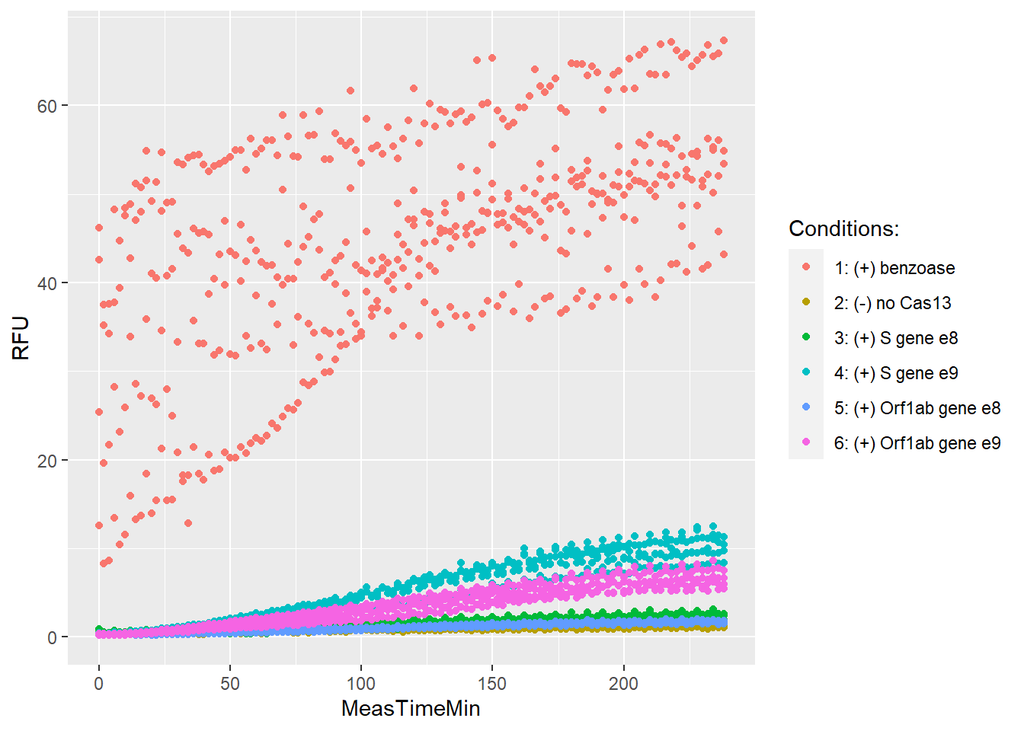

```r
# all the data
# plot(x=df$MeasTimeSec,y=df$RFU)

# colour by samples
ggplot(data = df) +
  aes(x = MeasTimeMin, y=RFU) +
  geom_point(aes(color=SampleNo)) +
  scale_color_discrete(name=name, breaks=IDs, labels=mylabels)
```

### Data adjustments if necessary

Removal of bad replicates and outliers

```r
## Adjustments - remove outliers if necessary

## Sometimes samples needs to be combined...
#  df$SampleComb <- df$SampleNo
#  df[df$SampleComb==2,"SampleComb"] <- 1

## Measurement of this sample have many outliers...
#  ggplot(subset(df, SampleNo %in% c(7))) +
#  aes(x = MeasTimeSec, y=RFU) +
#  geom_point(aes(color=SampleNo))

## Use summary statistics (mean) to find and remove obvious outliers...
#  means of all replicates
dfstat <- df %>% filter(SampleNo==1|SampleNo==2|SampleNo==3|SampleNo==4|SampleNo==5|SampleNo==6) %>% group_by(SampleNo,RepNo) %>% summarise(mean=mean(RFU))
print(dfstat,n=nrow(dfstat))
```

```
## # A tibble: 24 x 3
## # Groups:   SampleNo [6]
##    SampleNo RepNo   mean
##    <fct>    <chr>  <dbl>
##  1 1        1     37.2
##  2 1        2     57.9
##  3 1        3     37.7
##  4 1        4     46.9
##  5 2        1      0.773
##  6 2        2      0.883
##  7 2        3      0.874
##  8 2        4      0.999
##  9 3        1      1.08
## 10 3        2      1.45
## 11 3        3      1.51
## 12 3        4      1.69
## 13 4        1      4.10
## 14 4        2      6.03
## 15 4        3      5.32
## 16 4        4      5.68
## 17 5        1      0.926
## 18 5        2      1.17
## 19 5        3      0.956
## 20 5        4      1.09
## 21 6        1      2.88
## 22 6        2      4.24
## 23 6        3      3.20
## 24 6        4      3.76
```

```r
#View(dfstat)

# Data that should be removed
#dim(df)
#dim(df %>% filter(RepNo==1))
#dim(df %>% filter(RepNo!=1))
#df <- df %>% filter(RepNo!=1)

## To invert filter...
#  filter(df,SampleNo == 7 & RepNo == 3)
#  It is the same as leaving out all the measurement from some wells
#  df <- filter(df, Well != "A01" & Well != "B01" & Well != "C01"&  Well != "D01"& Well != "E01"& Well != "F01" & Well != "G01"& Well != "H01")

## Filter can be also inverted using...
#  df <- filter(df, Well != "G03")

## To remove some data...
#  There are some zeros (negative spikes) in Sample "7 1/3"
#  Let's removethose  zeros here
#  df[which(df$Sample=="7 1/3"&df$RFU==0),]
#  dfs[which(dfs$Sample=="7 1/3"&dfs$RFU==0),] <- NA

## Checks...
head(df)
```

```
##   Reading MeasTimeSec         Sample    RFU SampleNo RepNo MeasTimeMin
## 1       1        0.00 reaction_1 - 1 12.560        1     1    0.000000
## 2       2      120.32 reaction_1 - 1  8.298        1     1    2.005333
## 3       3      240.31 reaction_1 - 1  8.651        1     1    4.005167
## 4       4      360.31 reaction_1 - 1 13.410        1     1    6.005167
## 5       5      480.30 reaction_1 - 1 10.460        1     1    8.005000
## 6       6      600.34 reaction_1 - 1 11.540        1     1   10.005667
```

```r
length(rownames(df))
```

```
## [1] 2880
```

```r
length(complete.cases(df))
```

```
## [1] 2880
```

```r
table(is.na(df))
```

```
##
## FALSE
## 20160
```

```r
## only complete cases
df[which(is.na(df)),]
```

```
## [1] Reading     MeasTimeSec Sample      RFU         SampleNo    RepNo
## [7] MeasTimeMin
## <0 rows> (or 0-length row.names)
```

```r
df <- df[complete.cases(df),]
## check for NAs
```

### Panels of plots

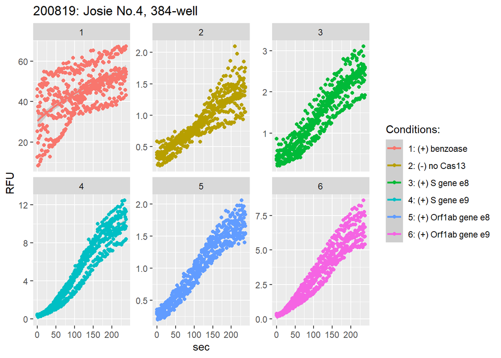

```r
## LOESS regression,
p <- ggplot(data = df) +
  aes(x = MeasTimeMin, y=RFU) +
  geom_smooth(aes(color=SampleNo)) +
  geom_point(aes(colour=SampleNo))

## Panel of plots fixed scale
p+facet_wrap(~SampleNo, scales = "free_y") +
  #coord_cartesian(xlim = c(0,500)) +
  labs(title = title, x = "sec", y = "RFU") +
  scale_colour_discrete(name=name, breaks=IDs, labels=mylabels)
```

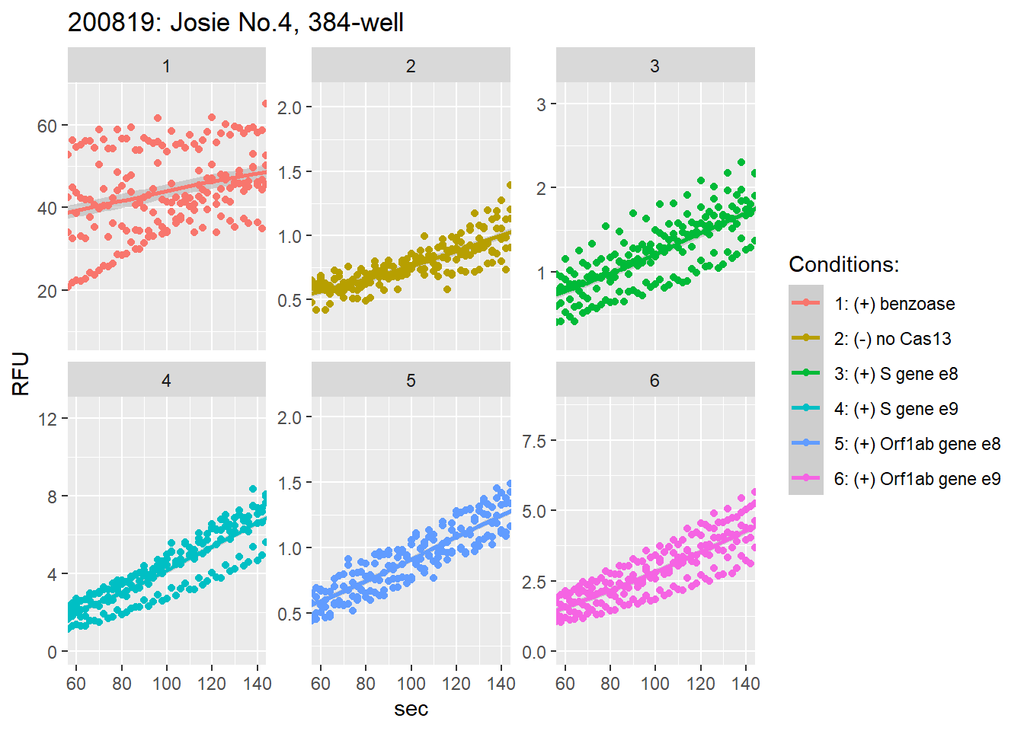

```r
## Panel of plots zoomed
p+facet_wrap(~SampleNo, scales = "free_y") +
  coord_cartesian(xlim = c(60,140)) +
  labs(title = title, x = "sec", y = "RFU") +
  scale_colour_discrete(name=name, breaks=IDs, labels=mylabels)
```

### Regression RFU~time plot

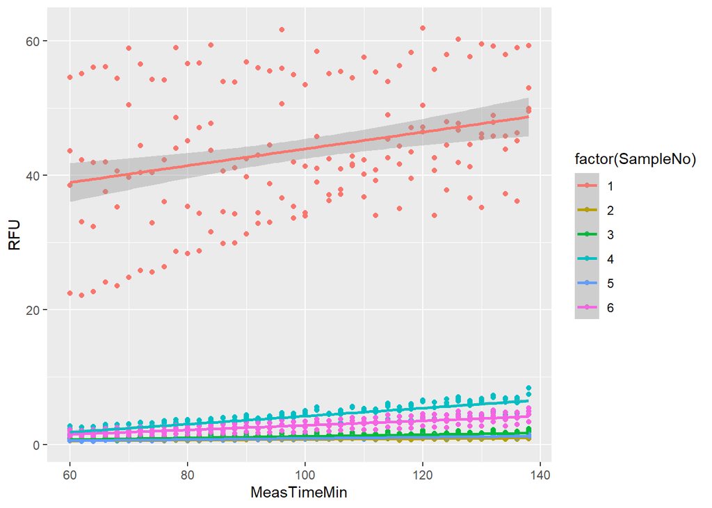

```r
# limit the time to where is appears to be the most linear
p <- ggplot(data=subset(df,MeasTimeMin>=60 & MeasTimeMin<=140), aes(x=MeasTimeMin,y=RFU,colour=factor(SampleNo))) +
geom_point() +
geom_smooth(method='lm',formula=y~x,se=T)

p
```

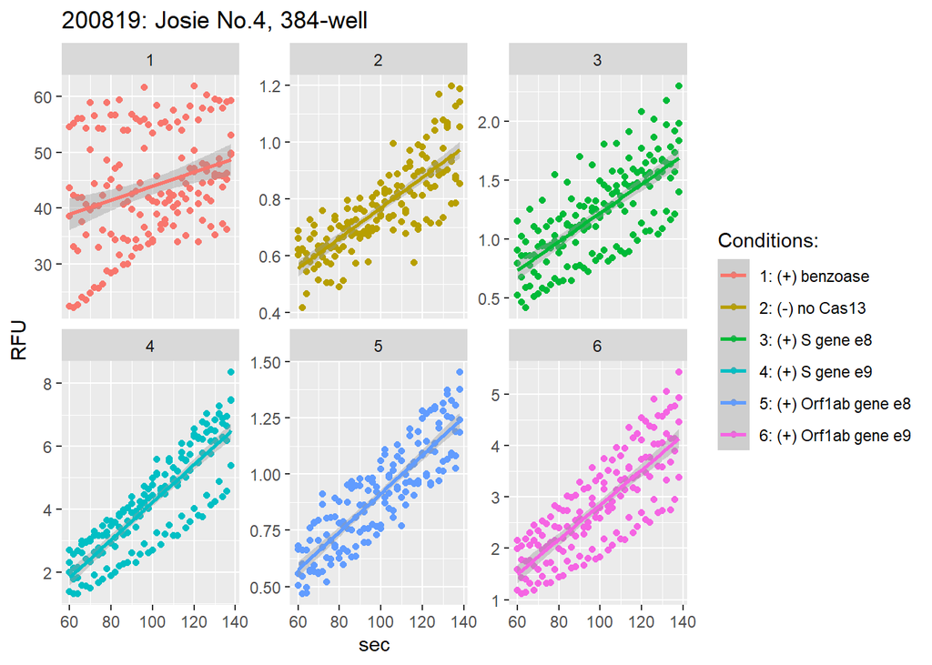

```r
## Panel of plots fixed scale
p+facet_wrap(~SampleNo, scales = "free_y") +
  #coord_cartesian(xlim = c(0,500)) +
  labs(title = title, x = "sec", y = "RFU") +
  scale_colour_discrete(name=name, breaks=IDs, labels=mylabels)
```

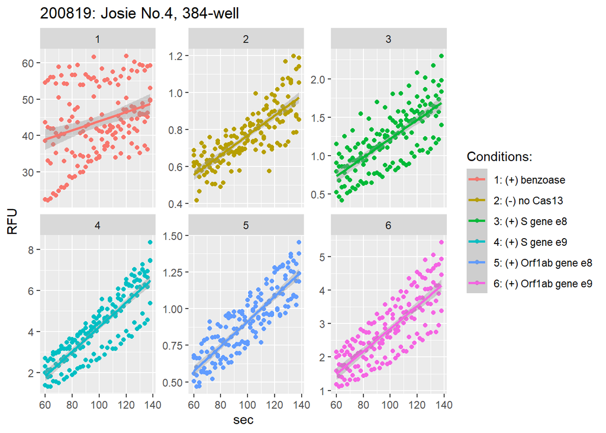

```r
p+facet_wrap(~SampleNo, scales = "free_y") +
  #coord_cartesian(xlim = c(4000,9000)) +
  labs(title = title, x = "sec", y = "RFU") +
  scale_colour_discrete(name=name, breaks=IDs, labels=mylabels)
```

#### Observation:

Obviously, most of the dfata are not withing 95% the confidence intervals.

## Example for one plot only

Copied form: [Regression on the plot](https://intellipaat.com/community/7335/adding-regression-line-equation-and-r2-on-graph)

Now we have to do it for all the samples.

### Now let’s put these solutions together

```r
## Now when we know how to limit regression
df  <-  subset(df,df$MeasTimeMin>60 & df$MeasTimeMin<=140)
head(df)
```

```
##    Reading MeasTimeSec         Sample   RFU SampleNo RepNo MeasTimeMin
## 31      31     3600.30 reaction_1 - 1 22.44        1     1    60.00500
## 32      32     3720.34 reaction_1 - 1 22.16        1     1    62.00567
## 33      33     3840.33 reaction_1 - 1 22.71        1     1    64.00550
## 34      34     3960.32 reaction_1 - 1 24.11        1     1    66.00533
## 35      35     4080.31 reaction_1 - 1 23.60        1     1    68.00517
## 36      36     4200.35 reaction_1 - 1 24.84        1     1    70.00583
```

```r
dim(df)
```

```
## [1] 960   7
```

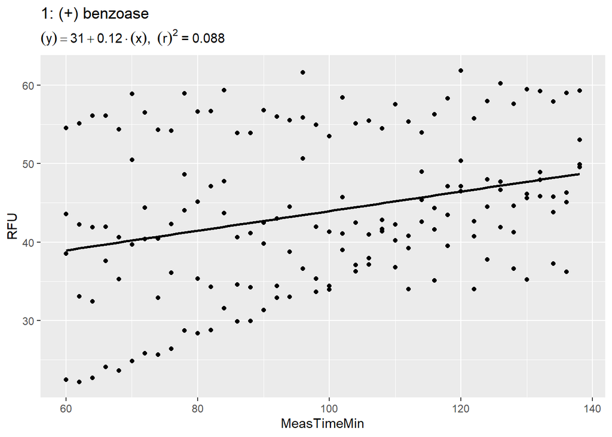

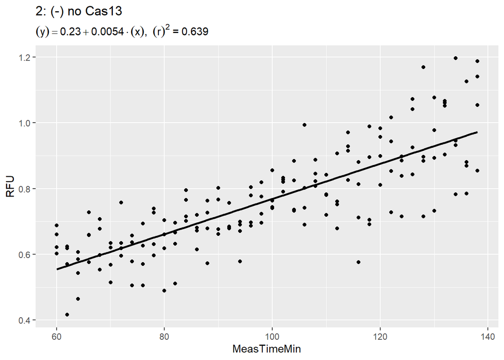

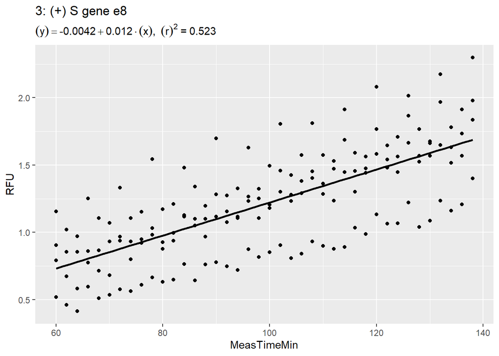

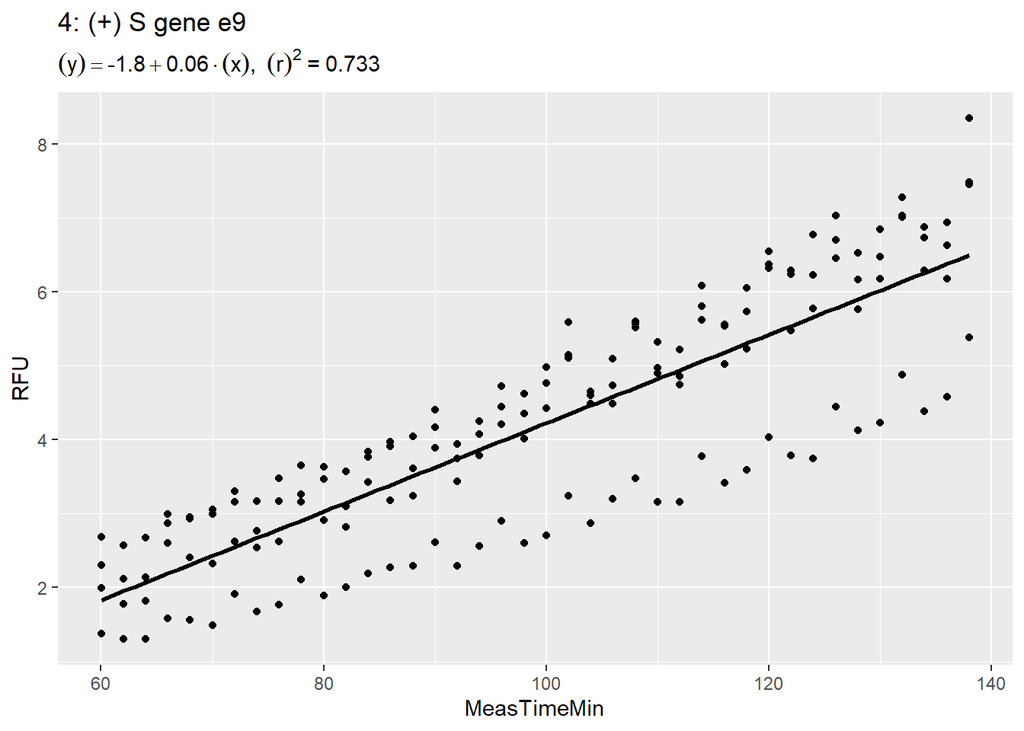

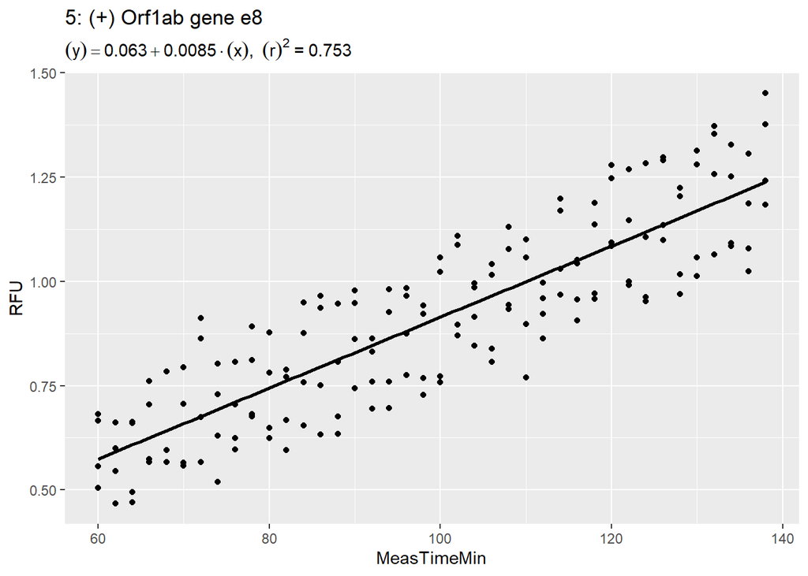

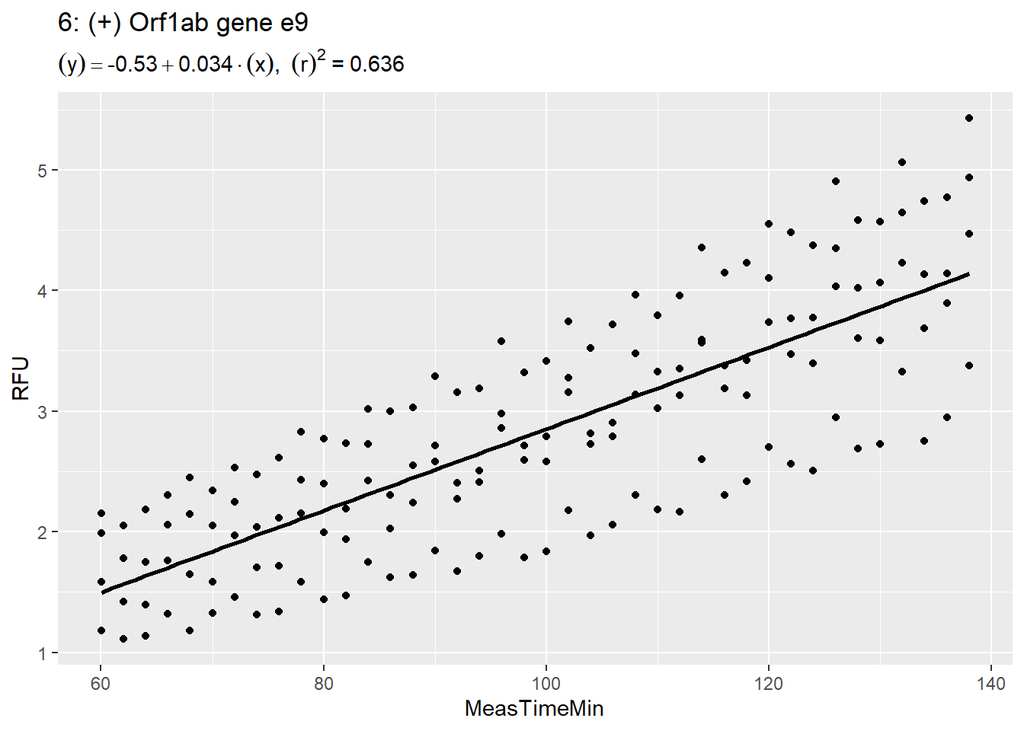

```r
#
# p <- df %>% group_by(SampleNo) %>% do(plots=ggplot(data=.) +
#          aes(x=MeasTimeSec, y=RFU) +
#            geom_point() +
#            geom_smooth(method = "lm", se=FALSE, color="black", formula = y ~ x) +
#            ggtitle(unique(.$SampleNo)))
# # print plots held by the object p
# print(p$plots)


# this writes regression equation
lm_eq <- function(df,x,y){
    m <- lm(y ~ x, df);
    eq <- substitute((y) == a + b %.% (x)*","~~(r)^2~"="~r2,
         list(a = format(unname(coef(m)[1]), digits = 2),
              b = format(unname(coef(m)[2]), digits = 2),
             r2 = format(summary(m)$r.squared, digits = 3)))
    as.expression(eq); # this works for title/subtitle
    # as.character(as.expression(eq)); # this works for geom_text
}


p <- df %>% group_by(SampleNo) %>% do(plots=ggplot(data=.) +
         aes(x=MeasTimeMin, y=RFU) +
           geom_point() +
           geom_smooth(method = "lm", se=FALSE, color="black", formula = y ~ x) +
           ggtitle(mylabels[unique(.$SampleNo)], subtitle = lm_eq(.,.$MeasTimeMin,.$RFU)))
          # geom_text(x = 25, y = 300, label = lm_eq(., .$MeasTimeSec, .$RFU), parse = TRUE))

# print plots held by the object p
#print(p$plots[1])
print(p$plots)
```

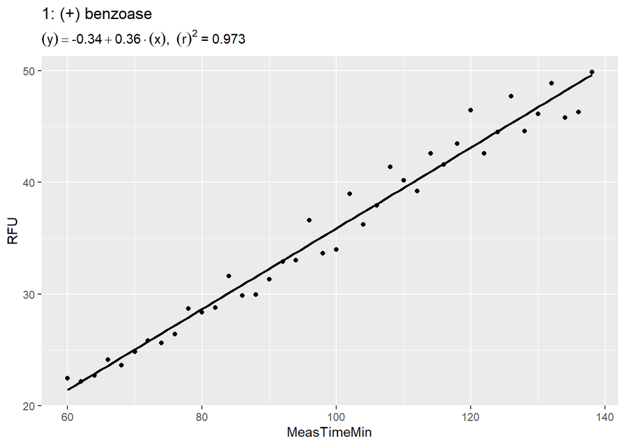

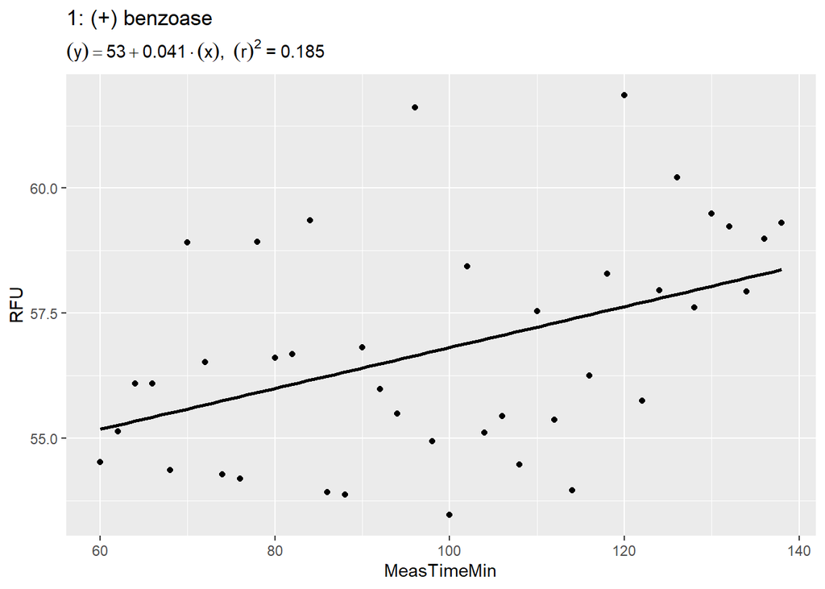

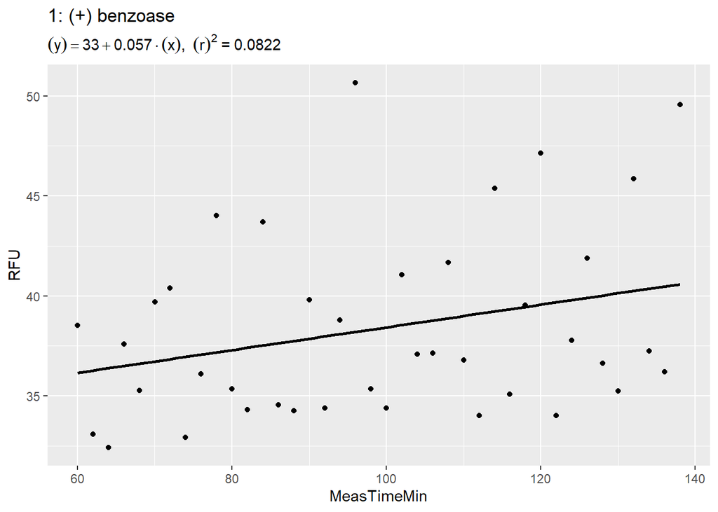

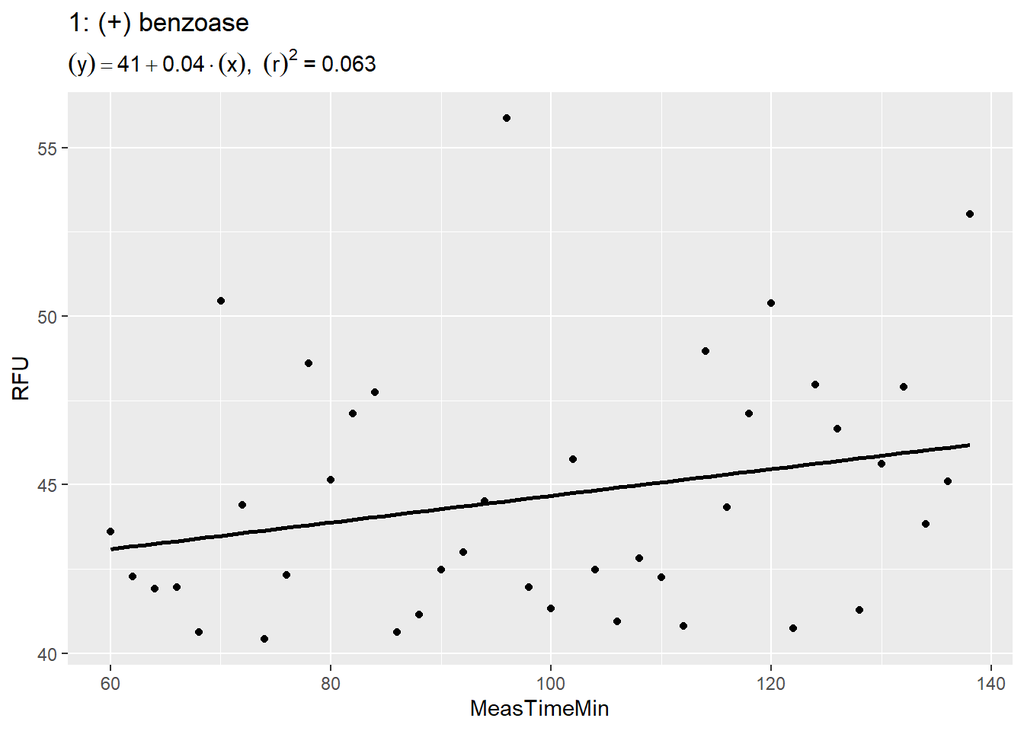

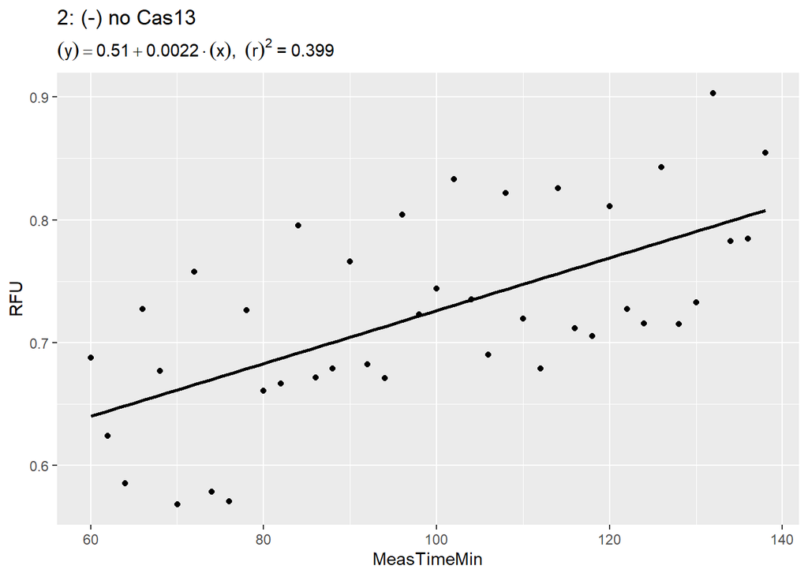

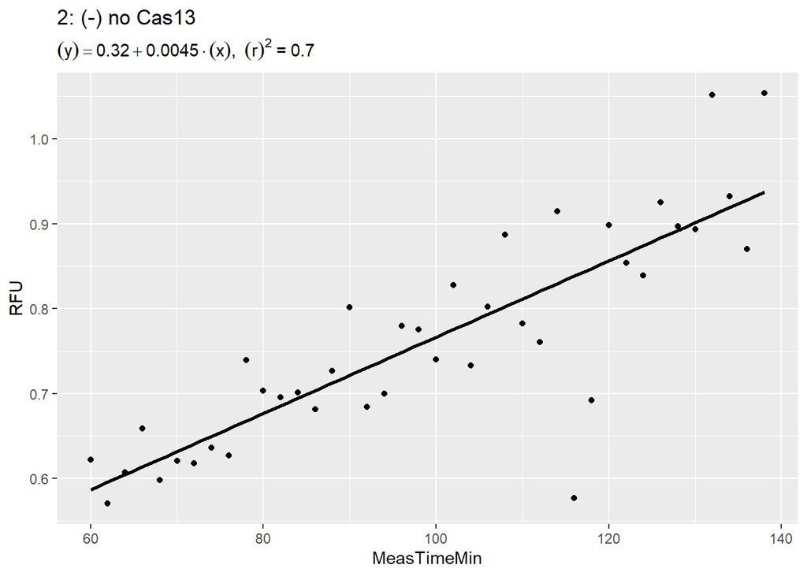

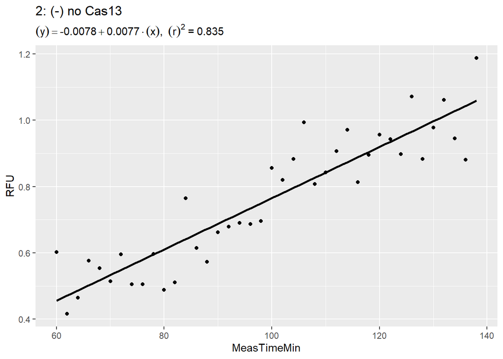

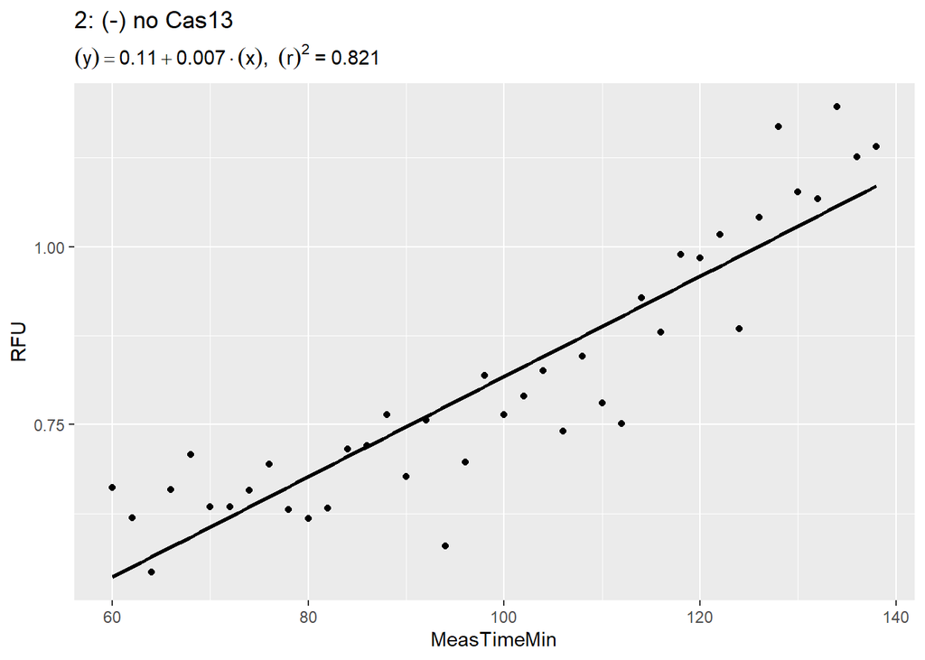

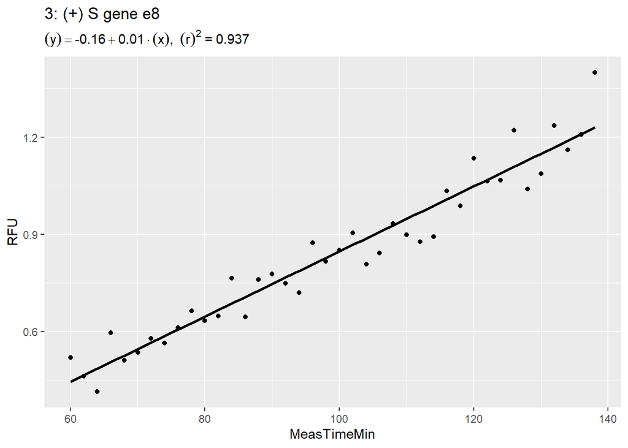

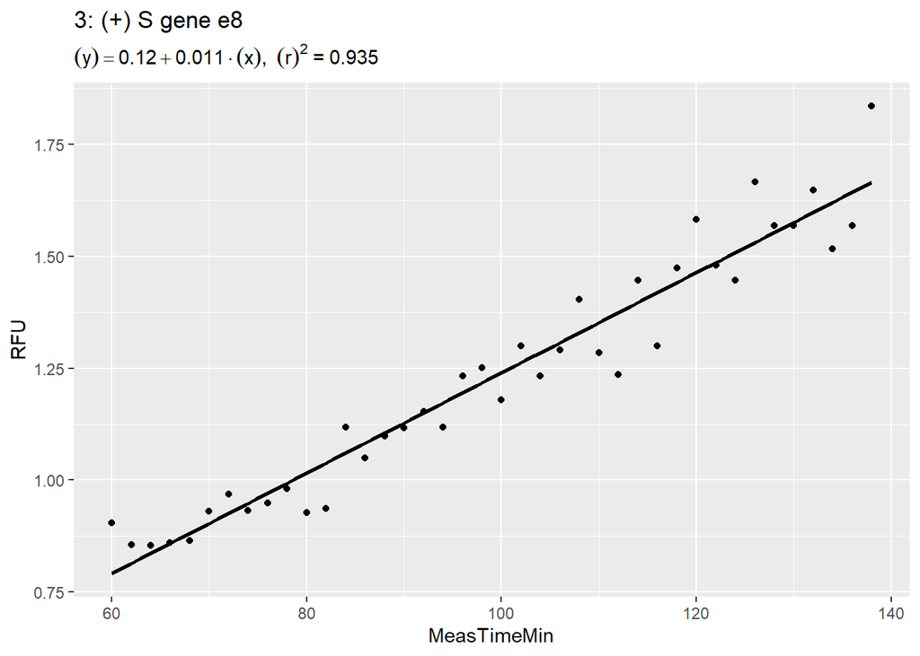

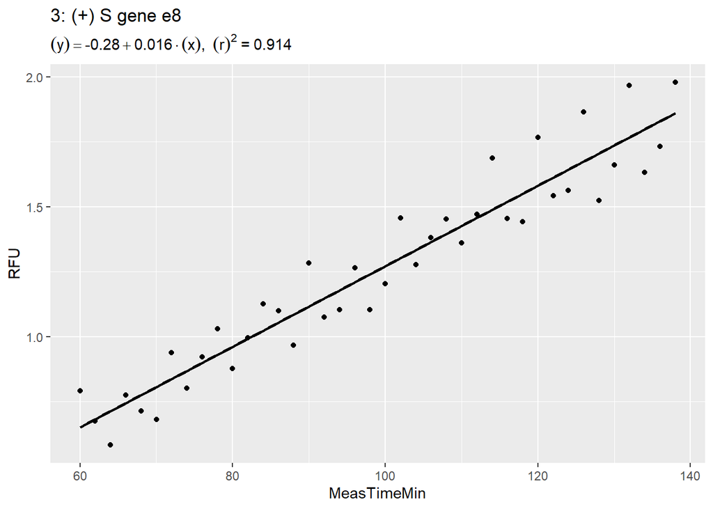

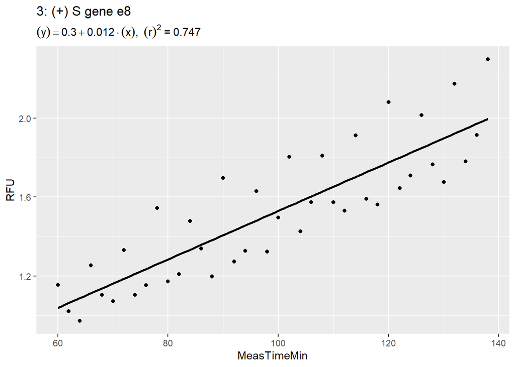

[12 more figures not shown]

```r
r <- df %>% group_by(SampleNo, RepNo) %>% do(plots=ggplot(data=.) + aes(x=MeasTimeMin, y=RFU) +
geom_point() +
geom_smooth(method = "lm", se=FALSE, color="black", formula = y ~ x) +
ggtitle(mylabels[unique(.$SampleNo)], subtitle = lm_eq(.,.$MeasTimeMin,.$RFU)))

print(r$plots)
```

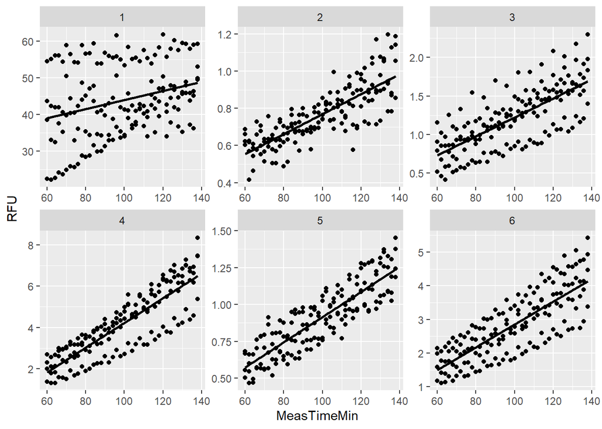

```r
## All together in a panel
# replicates together
df %>% group_by(SampleNo) %>% ggplot(data=.) +
         aes(x=MeasTimeMin, y=RFU) +
           geom_point() +
           geom_smooth(method = "lm", se=FALSE, color="black", formula = y ~ x) +
#           ggtitle(mylabels[unique(.$SampleNo)], subtitle = lm_eq(.,.$MeasTimeMin,.$RFU)) +
   facet_wrap(~SampleNo, scales = "free")
```

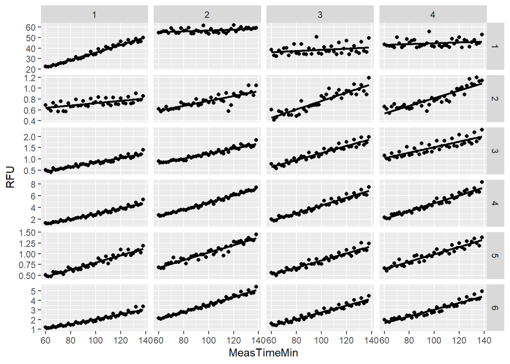

```r
# replicates separately
df %>% group_by(SampleNo, RepNo) %>% ggplot(data=.) +
         aes(x=MeasTimeMin, y=RFU) +
           geom_point() +
           geom_smooth(method = "lm", se=FALSE, color="black", formula = y ~ x) +
#           ggtitle(mylabels[unique(.$SampleNo)], subtitle = lm_eq(.,.$MeasTimeMin,.$RFU)) +
   facet_grid(SampleNo~RepNo, scales = "free")
```

## Gradients

### So what next? What is the best quantitative value for comparisons?

While it is nice to see the regression, what values are the best to compare for a robust quantitation? There are two the most obvious possibilities:

1. Sum of all RFU values for each over the whole time range.
2. Fit a linear regression to the time course and use the gradient for quantitative comparison.

The former method is the simplest.

The latter method shows all the details of the time course; Cas13a kinetics at fixed substrate concentration. The gradient is definitelly more robust than sum. But we have to check linearity RFU ~ time course.

Moreover, if the assay was well designed, and mesurement is taken above [S]>>Km, close to Vmax, perhaps we could calculate the tangent to plot dP/dt vs t like in: Claro, Enrique. (2000). Understanding initial velocity after derivatives of progress curves. Biochemistry and Molecular Biology Education. 28. 304-306? [link](https://www.sciencedirect.com/science/article/abs/pii/S1470817500000497)

```r
colnames(df)
```

```
## [1] "Reading"     "MeasTimeSec" "Sample"      "RFU"         "SampleNo"
## [6] "RepNo"       "MeasTimeMin"
```

```r
lin <- df %>% group_by(SampleNo) %>% do(lm(.$RFU ~ .$MeasTimeMin,data=.) %>% coef() %>% as_tibble())
library("tidyr")

lin$SampleNo <- as.numeric(factor(lin$SampleNo))
lin
```

```
## # A tibble: 12 x 2
## # Groups:   SampleNo [6]
##    SampleNo    value
##       <dbl>    <dbl>
##  1        1 31.5
##  2        1  0.125
##  3        2  0.233
##  4        2  0.00536
##  5        3 -0.00425
##  6        3  0.0123
##  7        4 -1.76
##  8        4  0.0598
##  9        5  0.0633
## 10        5  0.00851
## 11        6 -0.531
## 12        6  0.0338
```

```r
lin$lin_coef <- rep(c("a","b"),times=length(lin$SampleNo)/2)
lin
```

```
## # A tibble: 12 x 3
## # Groups:   SampleNo [6]
##    SampleNo    value lin_coef
##       <dbl>    <dbl> <chr>
##  1        1 31.5     a
##  2        1  0.125   b
##  3        2  0.233   a
##  4        2  0.00536 b
##  5        3 -0.00425 a
##  6        3  0.0123  b
##  7        4 -1.76    a
##  8        4  0.0598  b
##  9        5  0.0633  a
## 10        5  0.00851 b
## 11        6 -0.531   a
## 12        6  0.0338  b
```

```r
lin_wide <- lin %>% pivot_wider(., names_from=lin_coef, values_from=value)
lin_wide
```

```
## # A tibble: 6 x 3
## # Groups:   SampleNo [6]
##   SampleNo        a       b
##      <dbl>    <dbl>   <dbl>
## 1        1 31.5     0.125
## 2        2  0.233   0.00536
## 3        3 -0.00425 0.0123
## 4        4 -1.76    0.0598
## 5        5  0.0633  0.00851
## 6        6 -0.531   0.0338
```

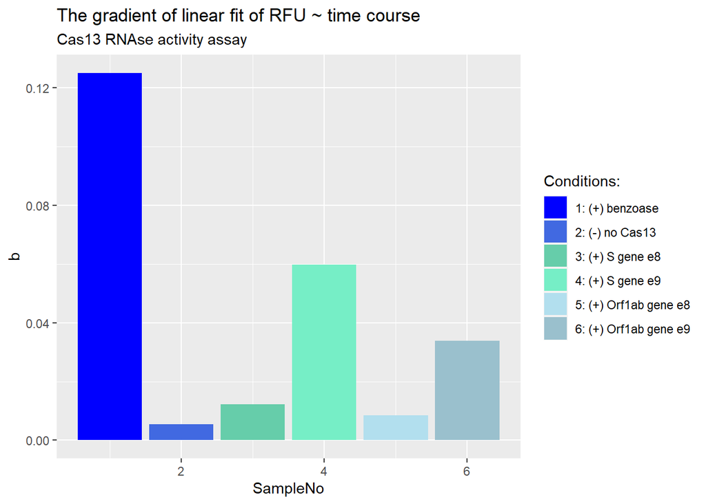

```r
# Why are some x-axis labels hidden?
# How to get x-axis labels replaced by someting more sensible - "mylabels"
# see [link](https://www.tutorialspoint.com/why-scale-fill-manual-does-not-fill-the-bar-with-colors-created-by-using-ggplot2-in-r)
# fill needs a factor


ggplot(lin_wide, aes(x=SampleNo, y=b, fill=as.factor(SampleNo))) +
  geom_bar(stat = "identity") +
  scale_fill_manual(name=name,labels=mylabels, values = mycolors) +
  labs(title = "The gradient of linear fit of RFU ~ time course", subtitle=mysubtitle)
```

```r
# The same plot coded in another way (base R)
op <- par(mar = c(8,4,4,2) + 0.1) ## default is c(5,4,4,2) + 0.1
op
```

```
## $mar
## [1] 5.1 4.1 4.1 2.1
```

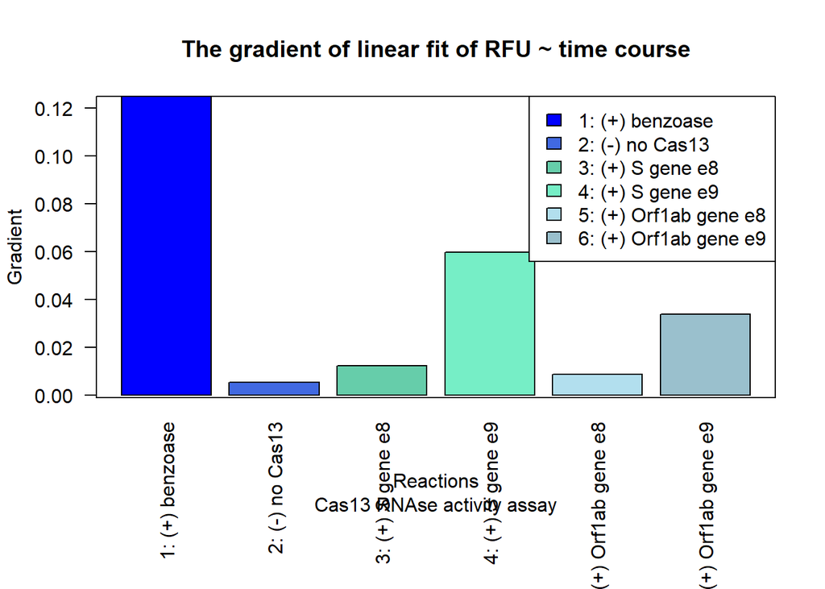

```r
barplot(lin_wide$b,
main = "The gradient of linear fit of RFU ~ time course",
sub = mysubtitle,
xlab = "Reactions",
ylab = "Gradient",
#names.arg = seq(1:6), las=1,
names.arg = mylabels, las=2,
col = mycolors,
horiz = FALSE)
box()

legend("topright",                                    # Add legend to barplot
       legend = mylabels,
       fill = mycolors)
```

### When we take replicates individualy…

```r
colnames(df)
```

```
## [1] "Reading"     "MeasTimeSec" "Sample"      "RFU"         "SampleNo"
## [6] "RepNo"       "MeasTimeMin"
```

```r
lin <- df %>% group_by(SampleNo, RepNo) %>% do(lm(.$RFU ~ .$MeasTimeMin,data=.) %>% coef() %>% as_tibble())
library("tidyr")

lin$RepNo <- as.numeric(factor(lin$RepNo))
lin
```

```
## # A tibble: 48 x 3
## # Groups:   SampleNo, RepNo [24]
##    SampleNo RepNo    value
##    <fct>    <dbl>    <dbl>
##  1 1            1 -0.343
##  2 1            1  0.362
##  3 1            2 52.7
##  4 1            2  0.0409
##  5 1            3 32.7
##  6 1            3  0.0568
##  7 1            4 40.7
##  8 1            4  0.0396
##  9 2            1  0.511
## 10 2            1  0.00215
## # ... with 38 more rows
```

```r
lin$lin_coef <- rep(c("a","b"),times=length(lin$RepNo)/2)
lin
```

```
## # A tibble: 48 x 4
## # Groups:   SampleNo, RepNo [24]
##    SampleNo RepNo    value lin_coef
##    <fct>    <dbl>    <dbl> <chr>
##  1 1            1 -0.343   a
##  2 1            1  0.362   b
##  3 1            2 52.7     a
##  4 1            2  0.0409  b
##  5 1            3 32.7     a
##  6 1            3  0.0568  b
##  7 1            4 40.7     a
##  8 1            4  0.0396  b
##  9 2            1  0.511   a
## 10 2            1  0.00215 b
## # ... with 38 more rows
```

```r
lin_wide <- lin %>% pivot_wider(., names_from=lin_coef, values_from=value)
lin_wide
```

```
## # A tibble: 24 x 4
## # Groups:   SampleNo, RepNo [24]
##    SampleNo RepNo        a       b
##    <fct>    <dbl>    <dbl>   <dbl>
##  1 1            1 -0.343   0.362
##  2 1            2 52.7     0.0409
##  3 1            3 32.7     0.0568
##  4 1            4 40.7     0.0396
##  5 2            1  0.511   0.00215
##  6 2            2  0.317   0.00449
##  7 2            3 -0.00785 0.00773
##  8 2            4  0.112   0.00705
##  9 3            1 -0.158   0.0101
## 10 3            2  0.119   0.0112
## # ... with 14 more rows
```

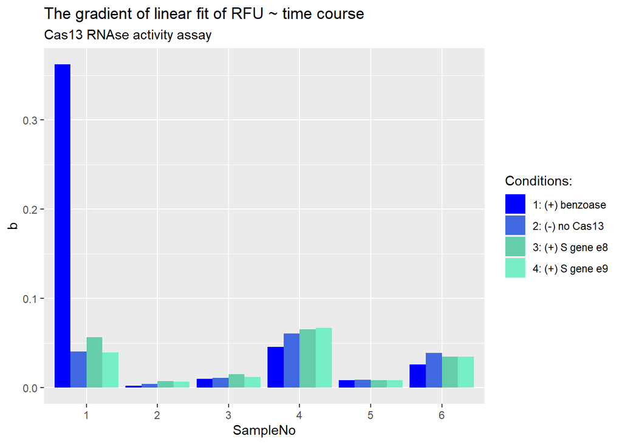

```r
# Why are some x-axis labels hidden?
# How to get x-axis labels replaced by someting more sensible - "mylabels"
# see [link](https://www.tutorialspoint.com/why-scale-fill-manual-does-not-fill-the-bar-with-colors-created-by-using-ggplot2-in-r)
# fill needs a factor


# plot replicate gradient
ggplot(lin_wide, aes(x=SampleNo, y=b)) +
  geom_bar(aes(fill=as.factor(RepNo)), stat = "identity", position = "dodge") +
  scale_fill_manual(name=name,labels=mylabels, values = mycolors) +
labs(title = "The gradient of linear fit of RFU ~ time course", subtitle=mysubtitle)
```

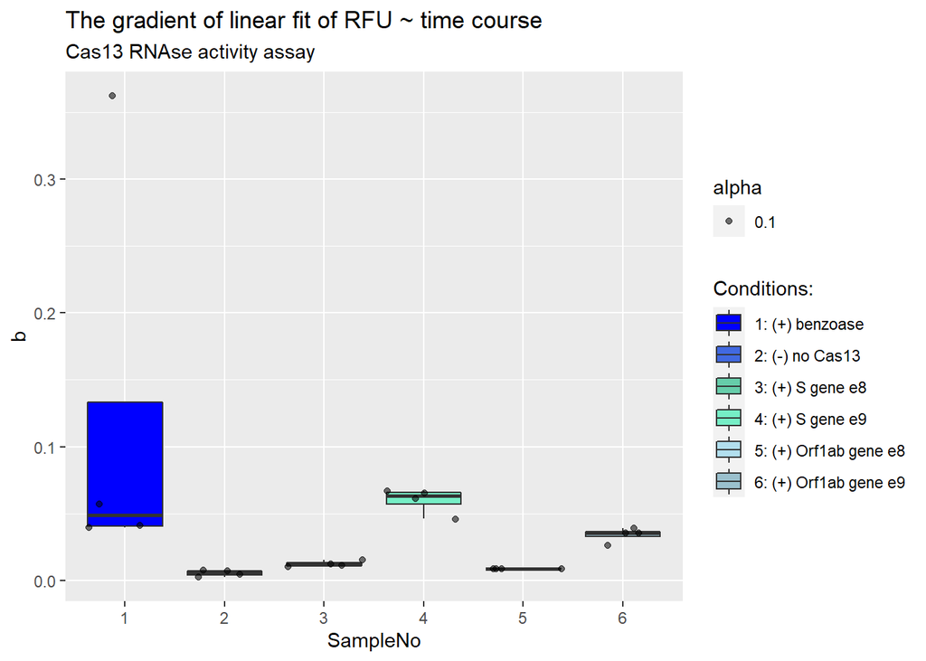

```r
# boxplot is the best
ggplot(lin_wide, aes(x=SampleNo, y=b)) +
  geom_boxplot(aes(fill=SampleNo), outlier.shape = NA) +
  geom_jitter(aes(alpha=0.1)) +
  scale_fill_manual(name=name,labels=mylabels, values = mycolors) +
  labs(title = "The gradient of linear fit of RFU ~ time course", subtitle=mysubtitle)
```

[figure not shown]

```r
# And for comparison,
# what we get when we sum all the data withing replicates...
ggplot(df, aes(x=SampleNo, y=RFU)) +
  geom_bar(aes(fill=RepNo), stat = "identity", position = "dodge") +
  scale_fill_manual(name=name,labels=mylabels, values = mycolors) +
    labs(title = "The sum of all data in RFU ~ time course",
         subtitle = mysubtitle)
```

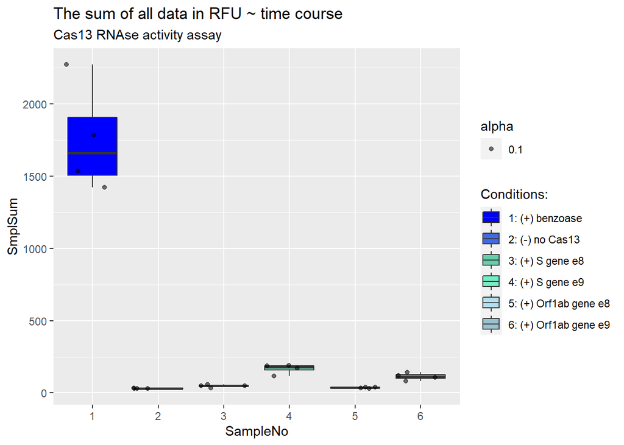

```r
# box plot of sums
s <- df%>% group_by(SampleNo, RepNo) %>% summarise(SmplSum=sum(RFU))
ggplot(s, aes(x=SampleNo, y=SmplSum)) +
  geom_boxplot(aes(fill=SampleNo), outlier.shape = NA) +
  geom_jitter(aes(alpha=0.1)) +
  scale_fill_manual(name=name,labels=mylabels, values = mycolors) +
  labs(title = "The sum of all data in RFU ~ time course", subtitle=mysubtitle)
```

```r
## What is the answer to what metrics is better, sum or gradient? THere is an obvious oulier in the positive control, that is clearly visible only when we calculate the regressions. But the linearity requirement is clearly more demanding on the data analysis.
## The total sum of RFU values shows quite a different picture. It woudl help to analyze more data to see what is correct and practical.
```

### Plots of subsets of samples and conditions to compare

Not used this time

### Notes

- Confidence intervals when all data points are treated independently are not very good
- Indeed, correlation coefficients evidence that
- It should help to calculate the gradient of each replicate individually, then calculate summary stats from all the replicates. It is a sensitive method to spot an odd sample, e.g there is an outlier in the positive control
- It is also possible to use the sum of all RFU values for a replicate, though the numbers are quite different. I think we need more data to be sure what is the best.